# Scare-off measures against wild boars

Computational Movement Analysis

Lia Baumann and Michele Senn

# Abstract

This project aims to develop a method for modelling the behavior of wild boars who have been in contact with scare-off measures. The hypothesis is that their behavior can be modeled by their distance to the corresponding Schreck, as well as comparing the average time they spent in a certain field before the scare-off measure called “Schreck” was put into action, during and after.

The distance of three boars named Caroline, Olga and Sabine to a Schreck in the region Fanel (WSS-2015-01) was visualized. The model depicts also the Schreck activity, which changed from standard to aggressive mode, and the moments when the boars spent time inside of the field where the Schreck was located. Additionally, the relative change in distance was shown as a second order effect.  
Though the behavior could be modeled by distance in a simple way, it is still lacking validation and the amount of data might not have been enough to draw conclusions. *(both)*

# Introduction

Due to an exceptionally high rate of reproduction and an abundant food supply, the wild boar population in Switzerland has been growing for centuries. As the population grows, so does the damage. According to Stefan Suter, the challenges of wild boar management cannot be met by hunting measures alone. For a successful wild boar management, a holistic approach is important. Prevention methods and limited access to energy-rich food will limit the population growth in wild boars. The wild boar deterrent developed at the ZHAW uses alarm and warning calls from wild boars to keep them out of the fields. Previous methods like electric fences and hunting are often not effective, time-consuming and expensive.[7]

To test the effectiveness of the developed deterrents around 150 wild boars were caught and marked in the test areas Fanel - a nature reserve at Lake Neuchâtel, Klingnau reservoir and upper Fricktal. Of these, 36 wild boars were fitted with GPS-GSM transmitter collars to document their spatial behaviour. In addition, the damage on the fields was determined with the help of drone aerial photographs. The knowledge gained in this way serves as the basis for a sustainable boar management.[7]

This project aims to develop a method for modelling the behaviour of wild boars who have been in contact with scare-off measures. Research questions are formulated, and it is described how those were investigated and implemented. The results will be presented and discussed in the light of the research questions. Potential further steps for future research will also be addressed. Problems and limitations encountered along the way and the solutions to overcome these, be it limitations with respect to the data sources, the tools or any other source of limitation will also be discussed. *(Michele)*

## Research Question

Once a scare-off measure has been set into action, it needs to be examined weather or not it has an effect. Therefore, the following research question was formulated:  
**How can the behavior of the boars who had been in contact with a Schreck be modelled?**

The hypothesis is that their behavior can be modelled by their distance to the corresponding Schreck, as well as comparing the average time they spent in a certain field before the scare-off measure called “Schreck” was put into action, during and after. *(Michele)*

Additionally, a second question was formulated, which was used to limit the scope of the research question:  
**How can a return pattern to the location of the Schreck be modelled?** *(Lia)*

## Data

Data about the “Schrecks” and their activity agenda, about the boars movement tracking and field data about the placement of the Schreck was used in this project. *(both)*

## Analytical concepts

Spatial and time overlaps between the tracked animals were plotted to get an idea of what the data looks like and finding patterns like which individual is affected by which Schreck.  
Distances to Scare-Off-Location over time were calculated using the st_distance() function, which returns the shortest distance that separates two geometries.  
The function st_intersects() provides intersection of geographical data points.  
With the Rolling Window method rollmean(), sampling size was reduced and compared to a sampling size reduction by omitting observations.  
To find returning patterns by building a “In the Field / not in the Field” vs. distance to Schreck graph, the application of joins and disjoints and appending a column with the binary data was implemented. *(both)*

## R concepts

The modelling was done using the following concepts and packages: Spatial objects were created and manipulated with the r-package “sf”. Raster data and background maps were plotted and visualized with these r-packages: “ggplot2” For the reshaping and transforming of data the r-package “tidyverse” was used. In the “zoo” package, the function rollmean() is contained, and arrangement of plots was partially done by using ggarrange() from “ggpubr”. *(both)*

## Risk analysis

The scope is considered a risk because of the amount of behaviors that could potentially be analysed. It is therefore advised to limit the scope. It was done by using a secondary research question. The Interpretation of behaviors might be vague or false because an emerging pattern is only correlated but not causal. Technical difficulties could also pose a risk, e.g. when handling too much data in the pre-processing stage, choosing irrelevant thresholds or interpretation issues (semantic annotations). Possibly, the different measures don’t show the same effects. It might be necessary to distinguish between measures in order to draw inferences. *(both)*

# 2. Methods

## 2.1 Data pre-processing

The data was loaded and converted into the coordination system crs = 2056. To find out, which boars were affected by which Schreck, the datasets were both transformed into the same coordinate system using st_transform. They were subsequently plotted on top of each other to visualize the spatial overlap. *(Lia)*

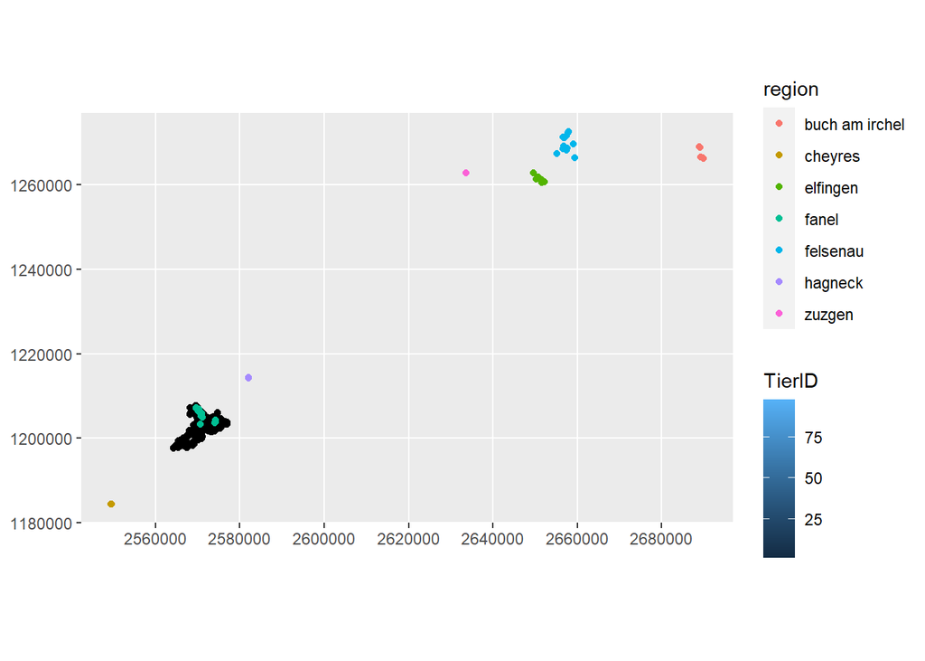

Apparently, the animals were only tracked around the Schreck in the region of Fanel. As a consequence, all other Schreck data points were removed and the spatial overlap replotted to validate the finding. *(Lia)*

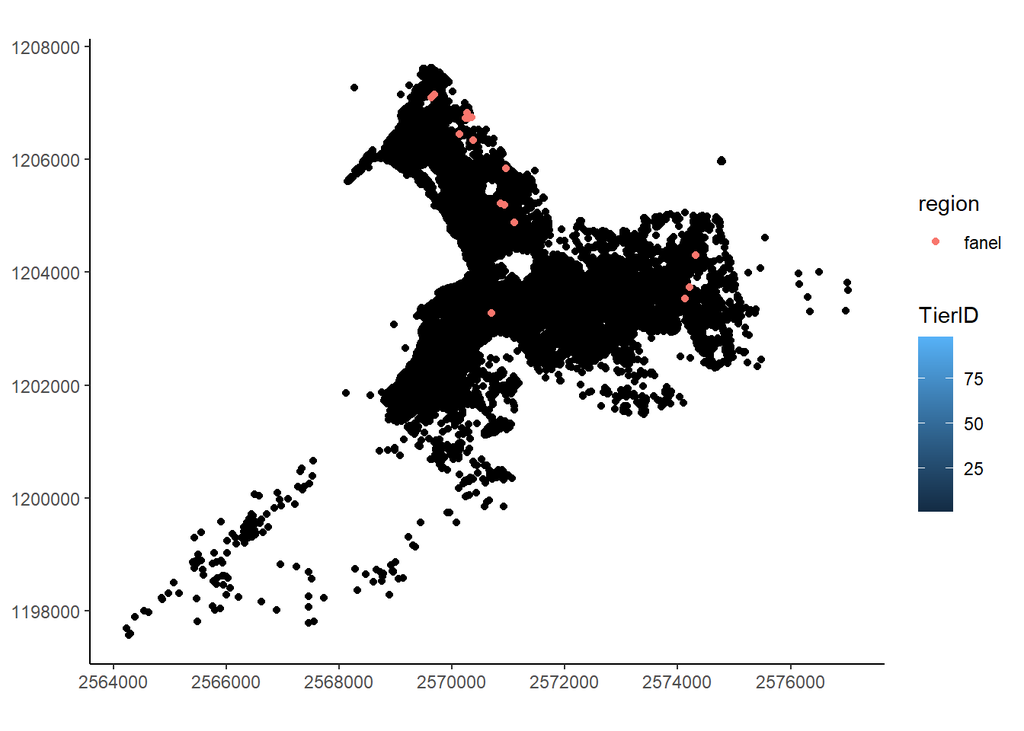

In order to combine the data about the Schreck locations and their corresponding agenda, or sounding time, they were joined by their matching column “id” with an inner join. Following this join, the agenda of all the “Schreck time” was visualized using an errorbar plot. Table 1 shows a table of the possibly relevant Schrecks as they were active at some point during the boar tracking time. *(Lia)*

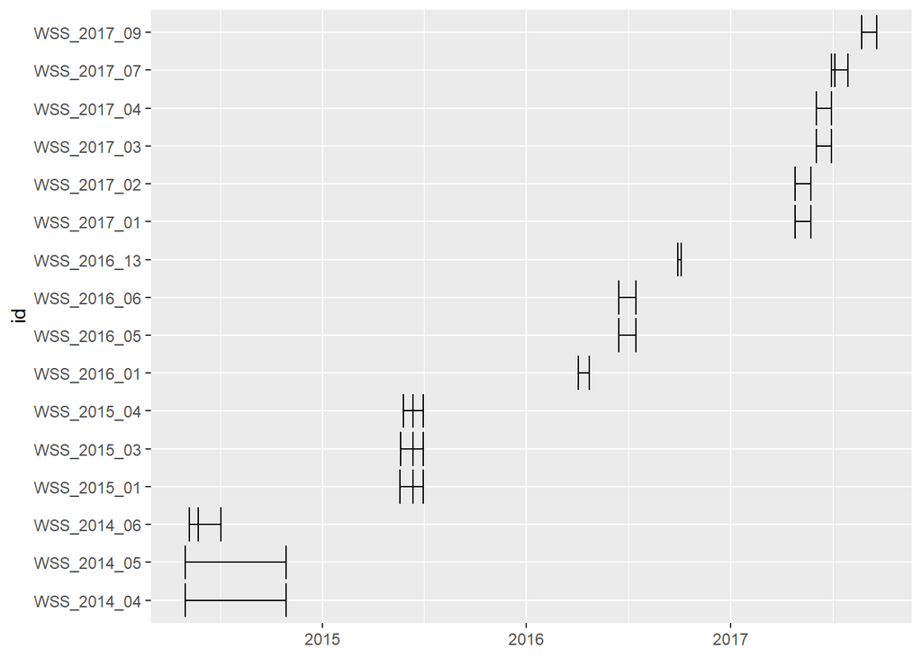

Table 1: All Schrecks in region Fanel during boar tracking time

| id | datum_on | datum_off | modus | geometry |
| --- | --- | --- | --- | --- |
| WSS_2014_04 | 2014-05-01 | 2014-10-28 | standard v1 | POINT (2570935 1205198) |
| WSS_2014_05 | 2014-05-01 | 2014-10-28 | standard v1 | POINT (2571106 1204878) |
| WSS_2014_06 | 2014-05-08 | 2014-05-24 | standard v1 | POINT (2569629 1207100) |
| WSS_2014_06 | 2014-05-24 | 2014-07-04 | aggressiv v1 | POINT (2569629 1207100) |
| WSS_2015_01 | 2015-05-20 | 2015-06-12 | standard v1 | POINT (2570864 1205214) |
| WSS_2015_01 | 2015-06-12 | 2015-07-01 | aggressiv v2 | POINT (2570864 1205214) |
| WSS_2015_03 | 2015-05-22 | 2015-06-12 | standard v1 | POINT (2569685 1207155) |
| WSS_2015_03 | 2015-06-12 | 2015-07-01 | aggressiv v2 | POINT (2569685 1207155) |
| WSS_2015_04 | 2015-05-27 | 2015-06-12 | standard v1 | POINT (2570247 1206737) |
| WSS_2015_04 | 2015-06-12 | 2015-07-01 | standard v1 | POINT (2570247 1206737) |
| WSS_2016_01 | 2016-04-04 | 2016-04-23 | standard v3 | POINT (2570699 1203282) |
| WSS_2016_05 | 2016-06-15 | 2016-07-15 | aggressiv v3 | POINT (2574315 1204308) |
| WSS_2016_06 | 2016-06-15 | 2016-07-15 | standard v3 | POINT (2570344 1206741) |
| WSS_2016_13 | 2016-09-29 | 2016-10-04 | aggressiv v3 | POINT (2570951 1205843) |

## 2.2 Selection of focus

In order to see which animals were tracked during the active period of the “Schreck”, the boar data was filtered by the dates in which the Schreck were active. For the tracked boars, a distance between their coordinates and the Schreck coordinate was calculated using st_distance(). In the following graph, one example of the resulting distances is shown. *(Lia)*

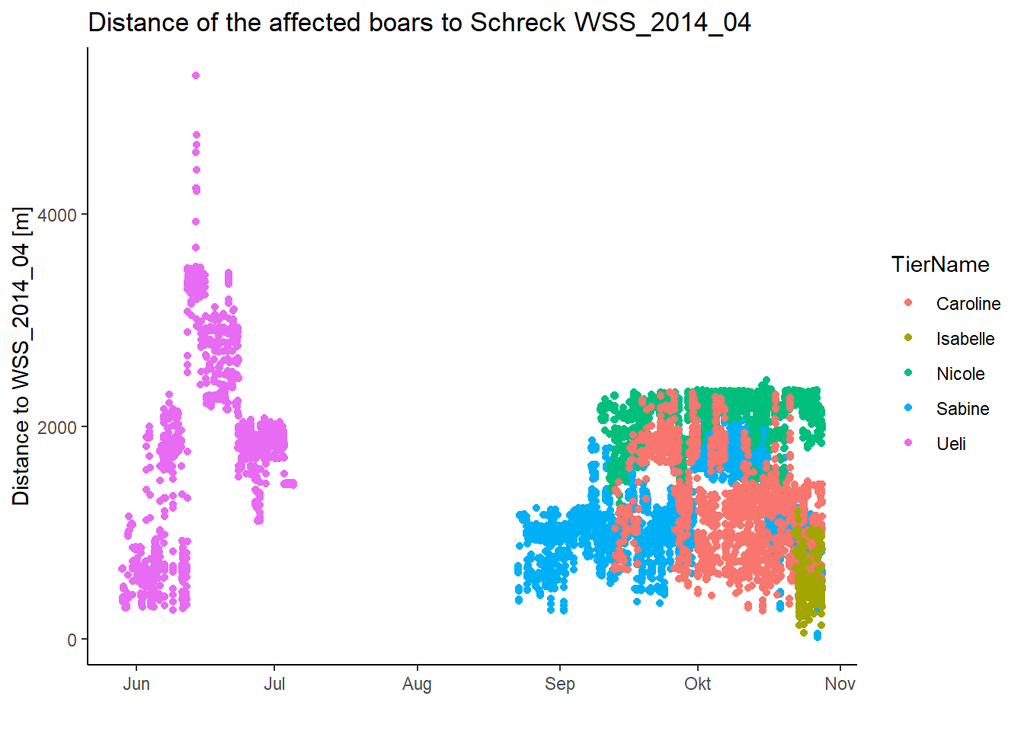

Since it isn’t known how close you would need to be to hear the Schreck, all of the five boars Caroline, Isabelle, Nicole, Sabine and Ueli could potentially have been affected.

Subsequenty, the same procedure was repeated for the other Schrecks in the Fanel region (results not displayed). *(Lia)*

All following conceptual steps were carried out with this focus.

## 2.3 Movement conceptualization: Distance to Schreck

Using the approach of calculating the distance of the boar to the Schreck plotted against the time provides insights about the movement radius around the Schreck during inactive and active times. *(Lia)*

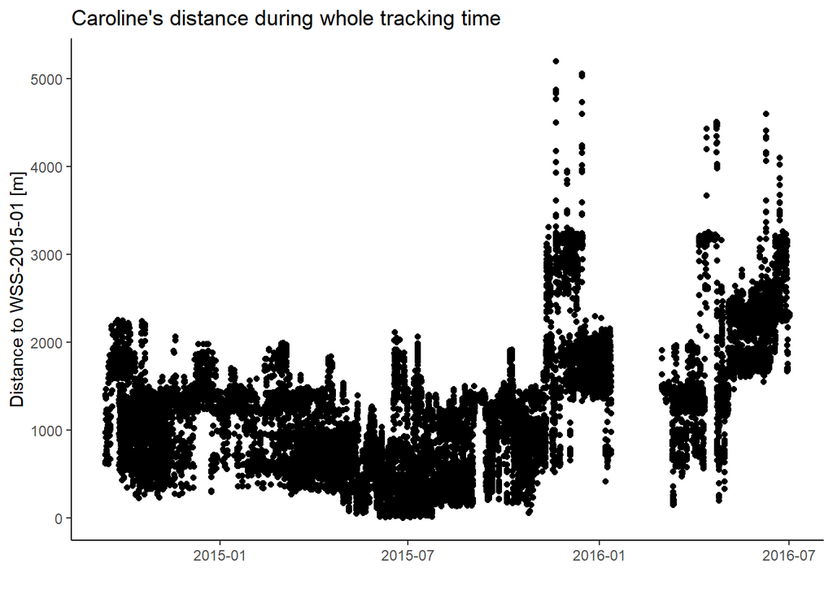

Zooming in for better understanding of the pattern:

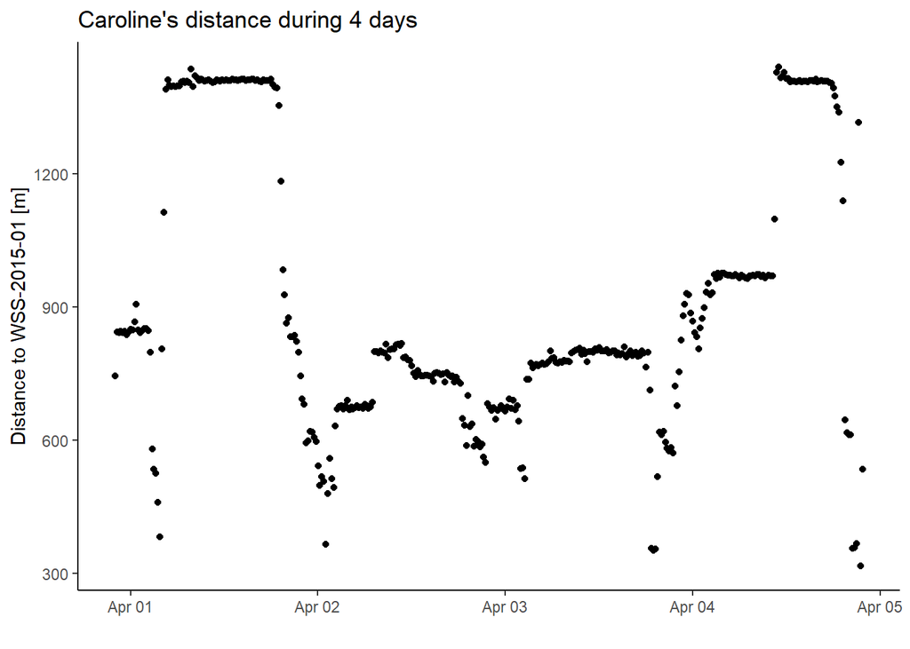

Caroline’s moving pattern shows her staying in one place during the days (mostly between 6-9 am to around 6pm). Speculation: That’s most likely when she’s sleeping. Movements, or better to say: changing of distances, are happening only at night, which was to be expected of a nocturnal animal. *(Lia)*

## 2.4 Relating locations to environment and defining field

As a next step, finding which kind of field this Schreck WSS-2015-01 is in, was done with the additional vector dataset “Feldaufnahmen_Fanel.gpkg” which provides geographical vector data about the agricultural fields in Fanel.  
The intersection of Schreck and corresponding field was located using “st_intersects” from the sf-package. *(Lia)*

```
## Sparse geometry binary predicate list of length 1, where the predicate
## was `intersects'
##  1: 272
```

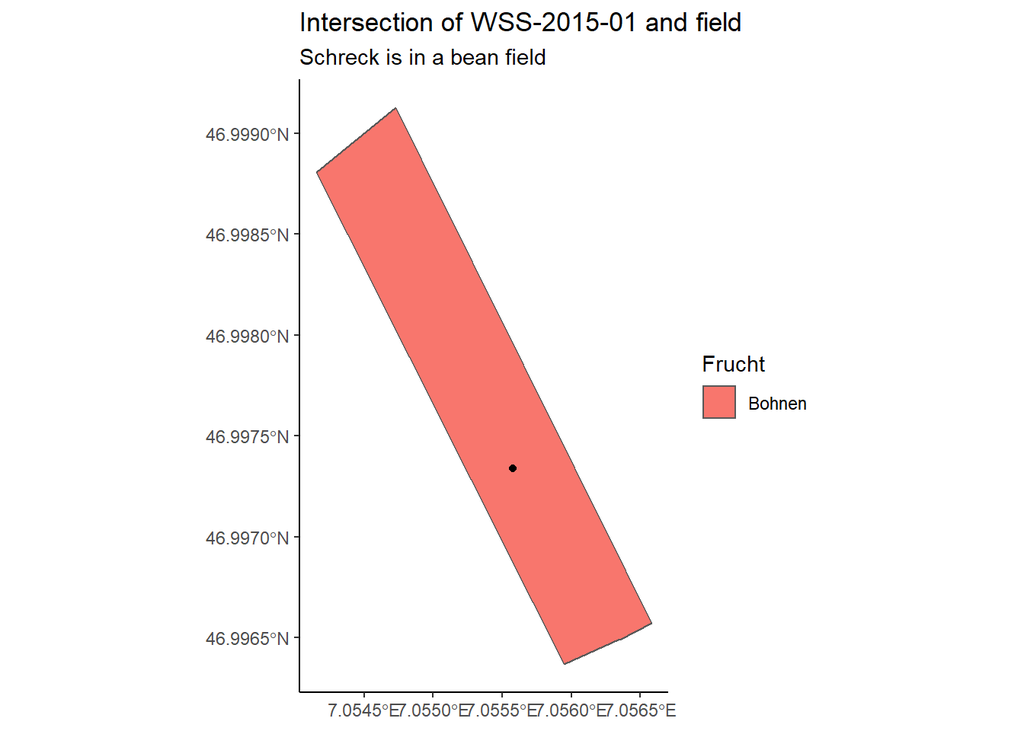

The following graphs show Caroline’s location around the bean field during active WSS-2015-01, first during standard mode and then during aggressive mode. These graphs seem to have an issue with scaling which makes it difficult to compare the spread of locations. *(Lia)*

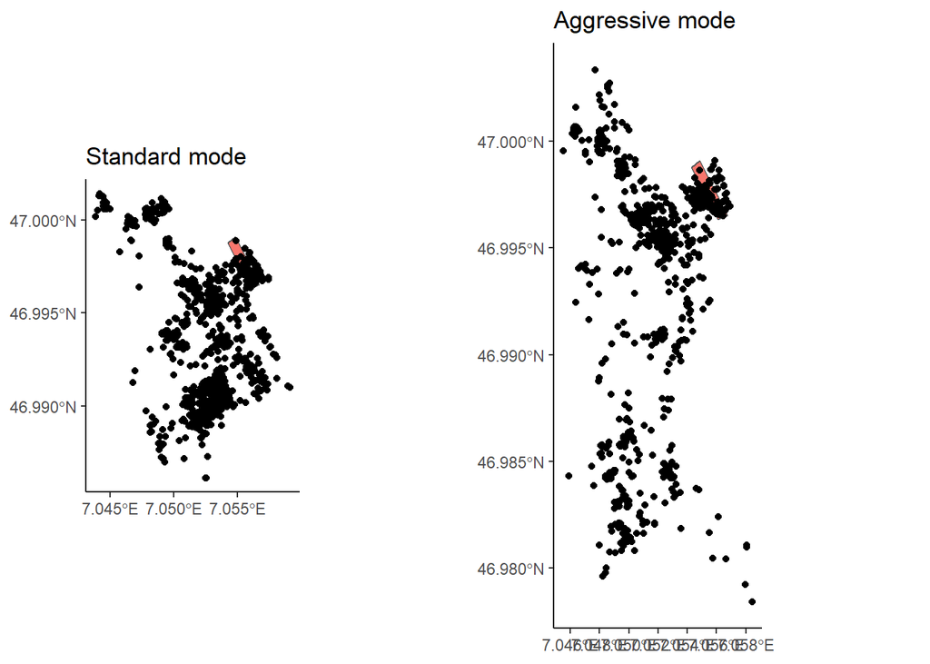

Looking at only the bean field:

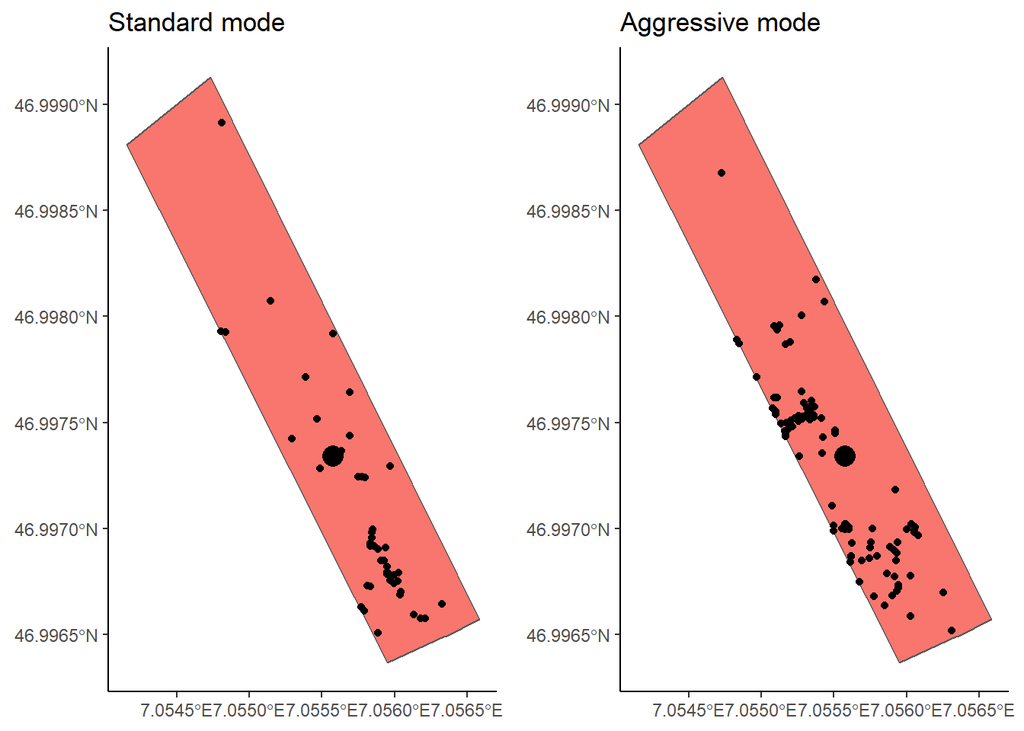

As can be seen, WSS-2015-01 is in a bean field (mode standard and then aggressive). Caroline made some visits during Schreck time.

In a similar way, the positions outside the bean field could be found by subsetting the dataset with st_disjoint() from the sf-package. *(Lia)*

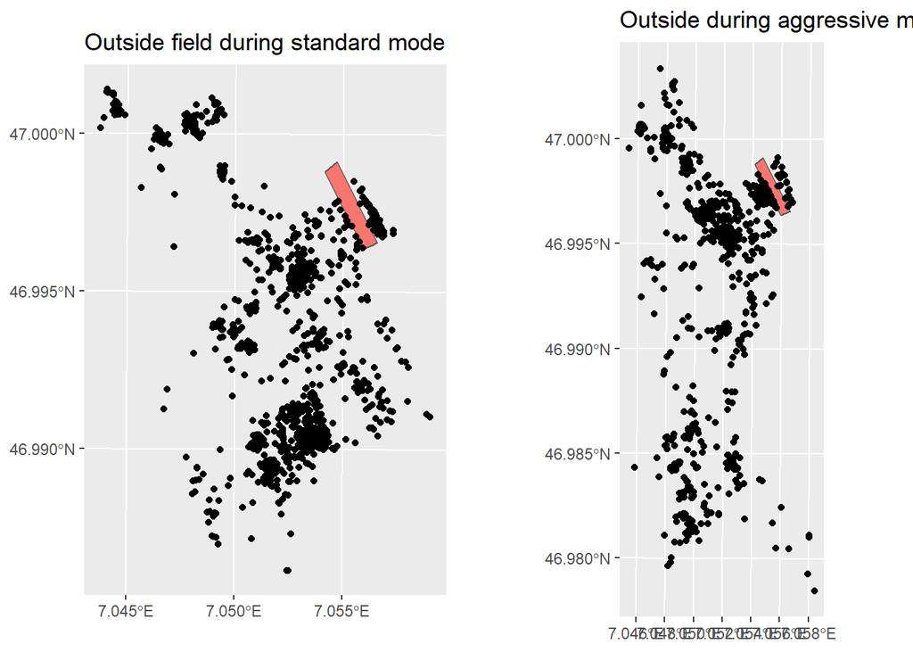

Using the information about the inside and outside positions, respectively, and adding binary information (1= “in field”, 0= “outside of field”), creates information about when Caroline was moving inside of the bean field and when not. The following graphs depict this concept by showing red points where Caroline was inside of the bean field. *(Lia)*

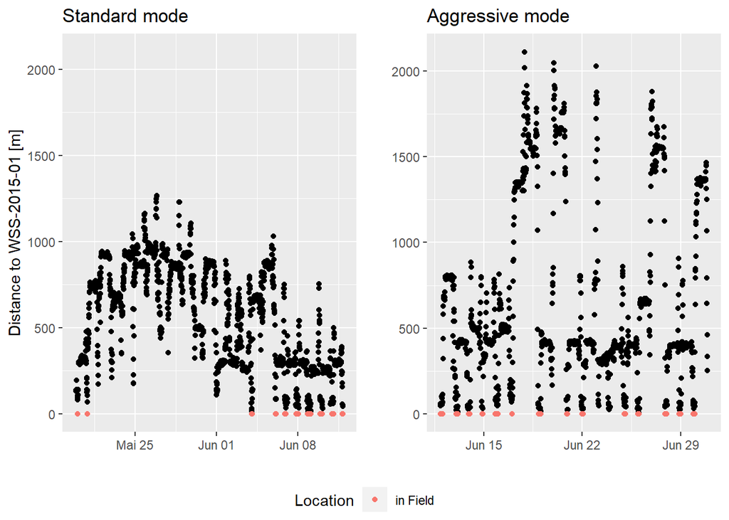

To show the distances or movements, respectively, not only during active Schreck times, but also before and after, the whole tracking time of Caroline was visualized. *(Lia)*

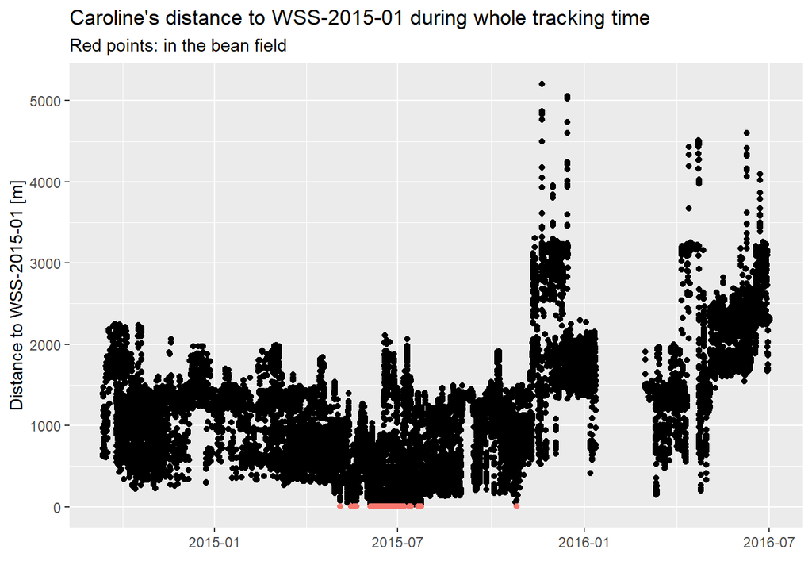

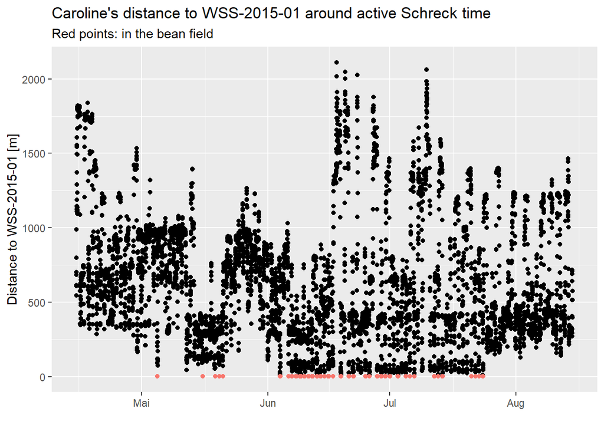

## 2.5 Displaying influence of Schreck activity

To conceptualize the active and inactive time of the Schreck, a background fill was used, provided with the function geom_rect() from ggplot2. *(Lia)*

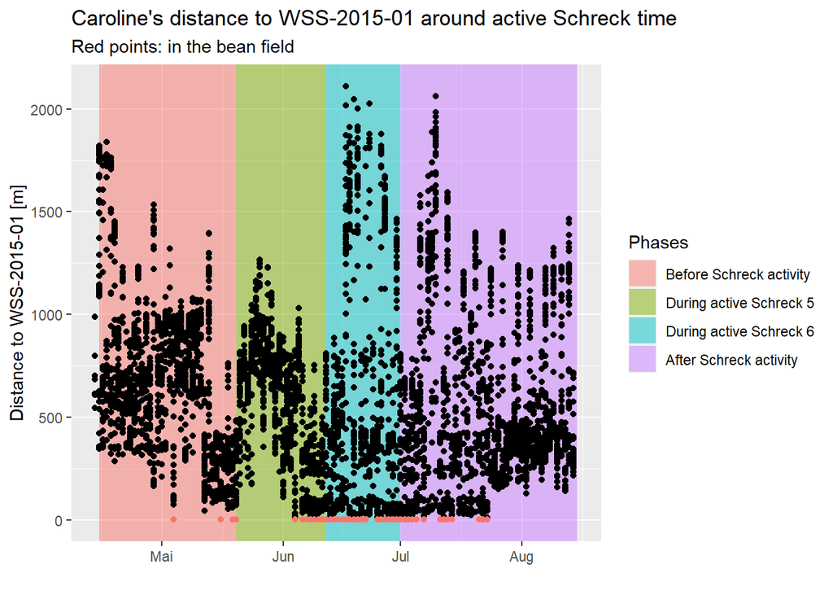

## 2.6 Evaluating complexity reduction

Subsequently, it was tested if complexity could be reduced by reduction of sampling size to every 50th and 150th observation (choice based on visual inspection). As a methodological comparison, smoothing was computed using the Rolling Window approach with a k of 10, 100 and 150. *(Lia)*

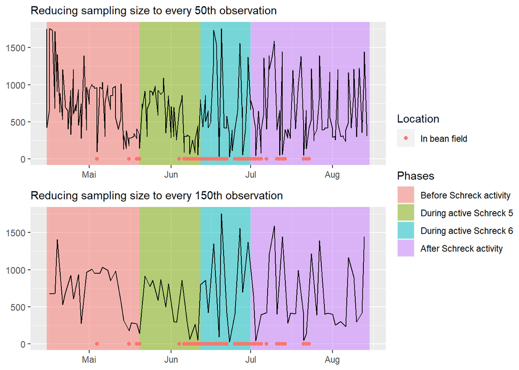

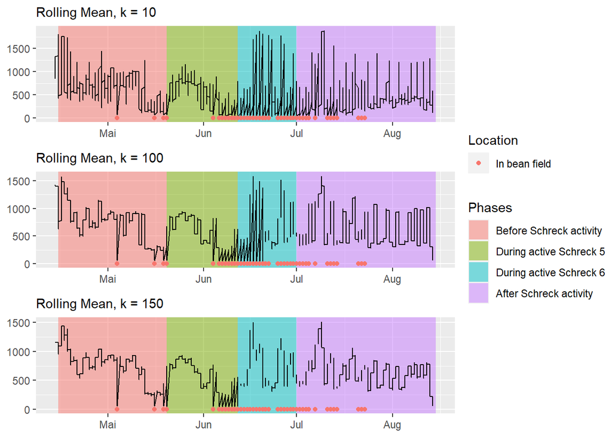

## 2.7 Extension of analyses to more boars

Olga’s and Sabine’s data were prepared following the same steps as was done with Caroline (preparation steps not shown). *(Lia)*

Validating the robustness of the methodolical approach was undertaken by visualization and comparison of their different positions around the bean field during active WSS-2015-01. *(Lia)*

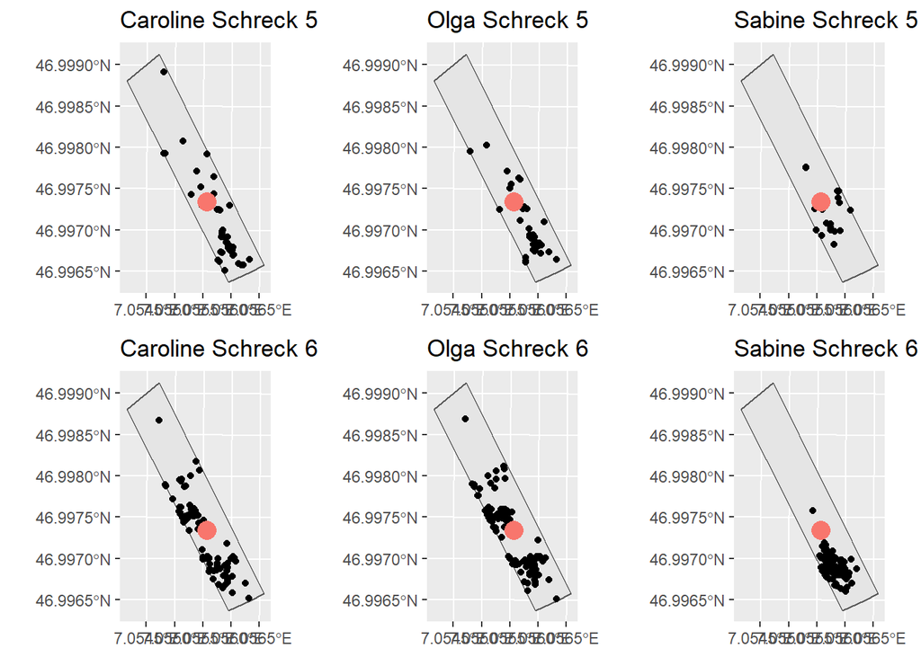

## 2.8 Visualising relative change of distance to Schreck

For completisation of the movement conceptualization, an additional visualisation was computed. What if the distance cannot depict the movement pattern, but the relative change of the distance provides more insight? Following this question, the relative change of distance during the same time period was plotted. It was calculated by grouping average daily and weekly distances and calculating their average change in %. The resulting graphs will be shown in the chapter “Results”. *(Lia)*

## 2.9 In the field vs. out of the field before, during and after Schreck action

In this approach the time of a boar inside a certain area is compared to the time spent outside of this area. The idea behind this approach was to gather information out of a rather large dataset that is relevant for a farmer and for the researcher, who but the scare-off measure called “Schreck” into place, to know if it has the effect of keeping the boars out of a certain area. Furthermore, this approach should provide some relative numbers with which a conclusion might be reached as to whether or not the scare-off measures have an effect on the boars.

The question which this approach seeks to answer is: How much time does a boar spend in the field before the Schreck (in %), during and after?

A binary approach in form of a inside vs. outside the field was used. The defined area is a certain field. This will be done for the period before the Schreck was put into action, during and after. The percentage of time spent inside the field vs. outside the field can then be compared between the timespan of before the Schreck was put into action, during and after.

As a first step the Schreck and boars for this approach had to be selected. It had to be Schrecks and boars were several animals were in the vicinity of a Schreck during its running period were there’s also enough tracking data of the boars movement from the period before the Schreck was put into action and from the period after the Schreck was active. This was done as described above. Schreck WSS_2015_01 was selected and the boars Caroline, Sabine and Olga, also as described in more detail above.

Next the area were the boars move around was mapped on a background map to get an idea of the terrain where the boars moved around. *(Michèle)*

[figure not shown]

[figure not shown]

# 3. Results

The final conceptualization of movement patterns of the three female boars is depicted in the following graph. The red points correspond to the position being inside of the bean field with the Schreck WSS-2015-01. Sampling size reduction to every 150th observation was chosen due to a sufficient resolution. Losing the information in between seems to be an acceptable compromise for the increase in readability. *(Lia)*

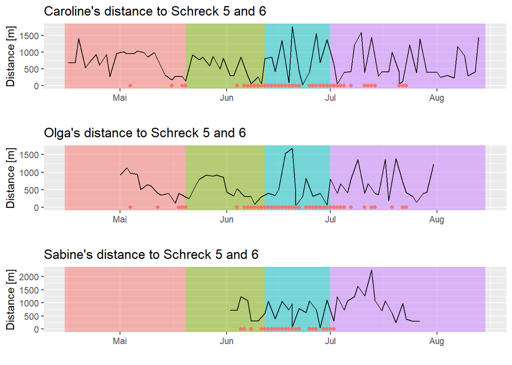

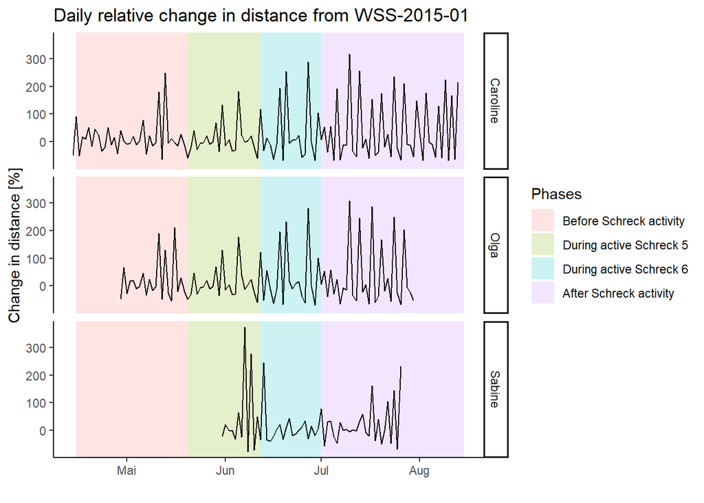

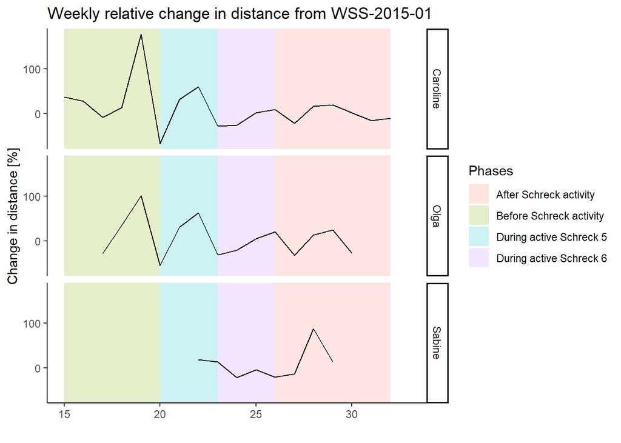

## In the field vs. out of the field before, during and after Schreck action

Schreck WSS-2015-01 is in a bean field (as described above). Caroline seems to be spending 0.03 % of her time in that field before the Schreck was put there, 2 % of her time during the Schrecks active period regardless if it’s in aggressive mode or not and 0.1 % of her time after the Schrecks active period.

Sabine seems to be spending 0 % of her time in that field before the Schreck was put there, 0.9 % of her time during the Schrecks active period while it was in normal mode, 7 % of her time while the Schreck is in aggressive mode and 0.2 % of her time after the Schrecks active period.

Olga seems to be spending 0.4 % of her time in that field before the Schreck was put there, 2 % of her time during the Schrecks active period, 6 % of her time during the Schrecks active period in aggressive mode and 0.06 % of her time after the Schrecks active period. *(Michèle)*

```
## Sparse geometry binary predicate list of length 1, where the predicate
## was `intersects'
##  1: 272
```

```
## Sparse geometry binary predicate list of length 1, where the predicate
## was `intersects'
##  1: 272
```

```
## [1] 0.8608971
```

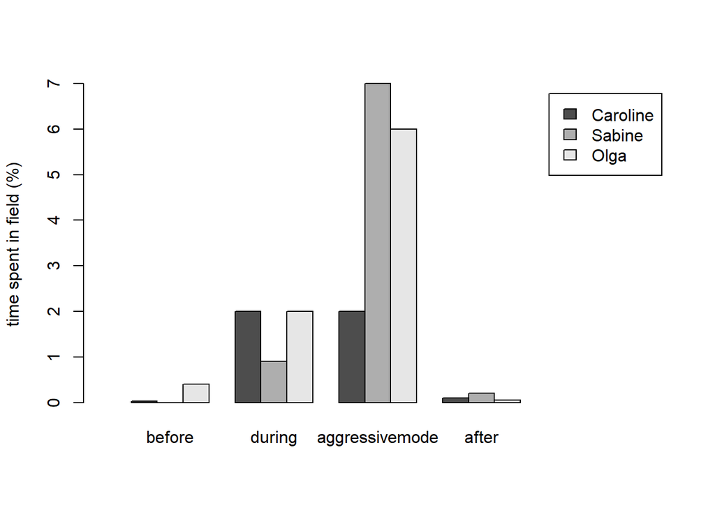

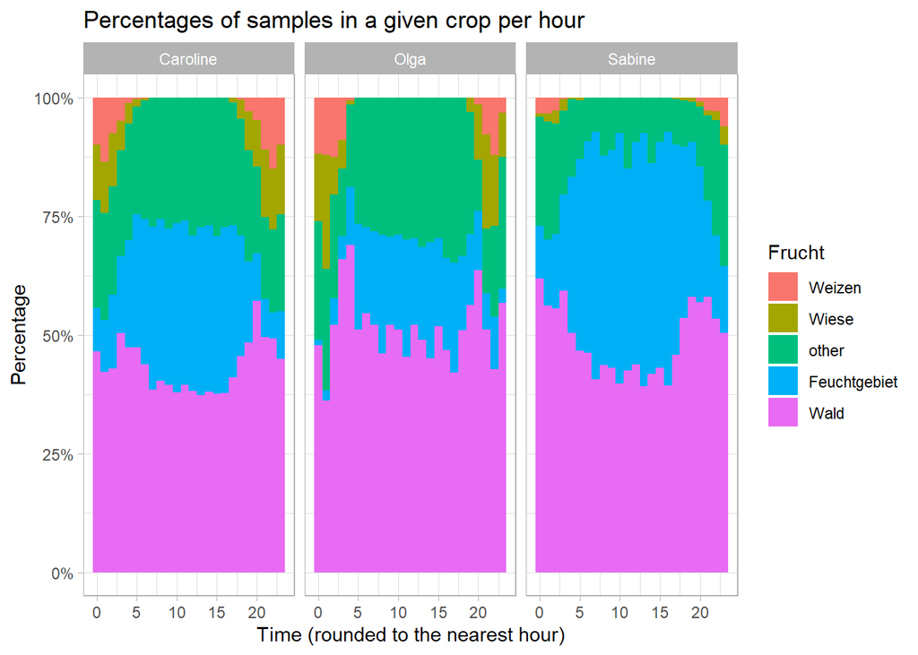

In order to validate this their whereabouts were plotted before, during and after the Schrecks active period. To visualize whether or not they were inside the field in which the Schreck was placed, the area of the field is marked in the plot. *(Michèle)*

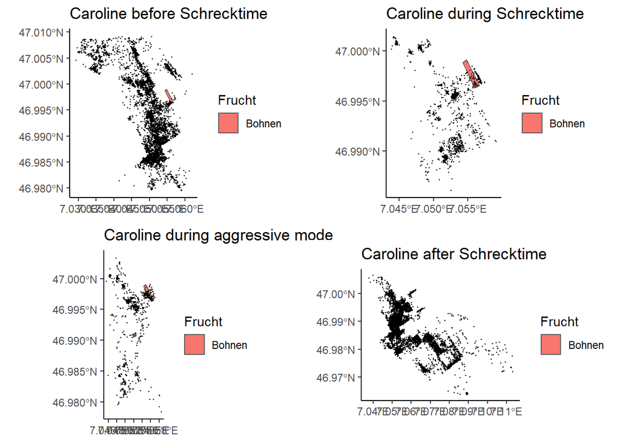

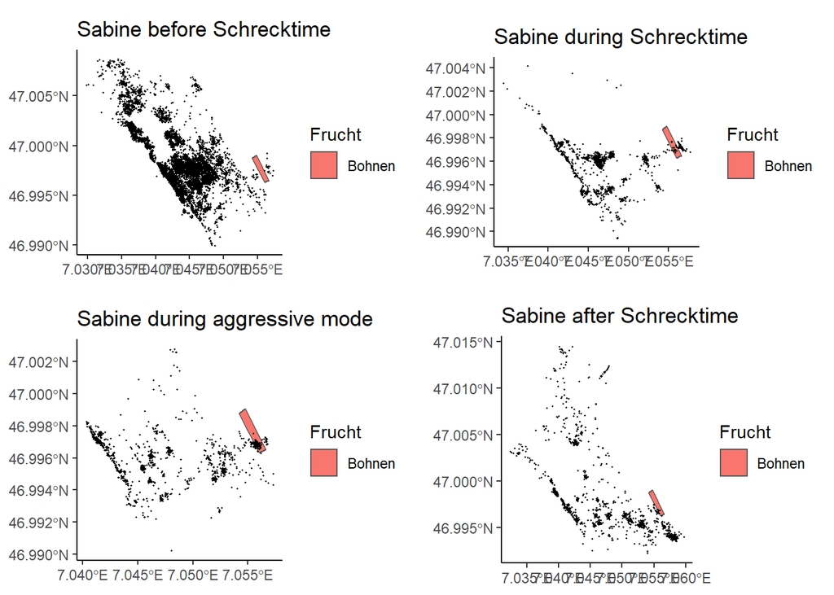

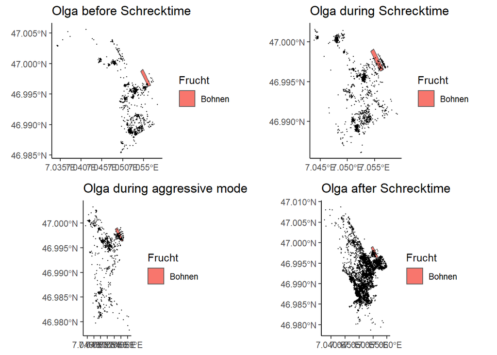

# 3. Discussion

This project aimed to develop a method for modelling the behaviour of wild boars who have been in contact with scare-off measures. Once a scare-off measure has been set into action, it needs to be examined weather or not it has an effect. Therefore, the following research questions were formulated:  
**How can the behavior of the boars who had been in contact with a Schreck be modelled?**

**How can a return pattern to the location of the Schreck be modelled?**

The hypothesis was that their behavior can be modelled by their distance to the corresponding Schreck, as well as comparing the average time they spent in a certain field before the scare-off measure called “Schreck” was put into action, during and after. *(Michele)*

## 3.1 Distance to conceptualize movement

The above explained topic was assessed by using another way of conceptualizing the distance: looking at the relative change of distance in relation to the last day or week (Idea from (4)). It could be considered as distinguishing between first order and second order effects (3).  
Looking at the resulting graphs, it can’t be concluded that this measure provides a more useful pattern. At least, the findings from the distance graphs can be reproduced this way (especially the similarity between Olga and Caroline) which could be considered as a validation step. *(Lia)*

# 3.2 In Field vs. Not In Field

The original concept to annotate the times when the boars were inside of the bean field resulted in a creation of point at “in Field” moments. The binary display of In vs. Not In didn’t provide any useful pattern. In the results, red points can be seen and followed, and interestingly, the boars were visiting the field even during Schreck time. Not even the aggressive mode during activity stopped them from returning to the field.  
This concept could start the analysis of finding returning patterns, though more validation would need to be executed. *(Lia)*

In this approach the time of a boar inside a certain area was compared to the time spent outside of this area, which should produce a conclusion out of a large dataset which is relevant and understandable for a farmer as well as for the researcher, who put the scare-off measures into place. It should provide a conclusive answer on whether or not the Schreck has the effect of keeping the boars out of a certain area.

The question which this approach aimed to answer is: How much time does a boar spend in the field before the Schreck (in %), during and after?

This method delivers relative numbers with which a conclusion can be reached. However for those percentages to be valid enough to reach a statistical conclusion and to decide if an observed effect is significant or not, more data would be needed. Several animals would need to be tracked during the same time period in the same area, so that the data could be compared and have some statistical weight and that finally an effect could be called significant. This poses a challenge however, since several animals would have to be caught and have a tracker attached to them at the same time, which might be unrealistic. Furthermore, those animals would have to move around in the same area, which is something the researchers have no control over. Therefore the data gained by tracking wild boars is difficult to interpret and should be weighted carefully. There might be a great number of reasons for an observed effect, such as the personality of the boar itself, the geographic region, the season, etc. This approach can only deliver meaningful and reliable results, if a statistically significant number of individuals is tracked during the same time period and the same area. If that is not possible, drone data on the caused damage might the more reliable indicator on the effectiveness of the Schrecks. *(Michele)*

## 3.3 Smoothing methods

Counting as an interesting finding was the fact that the boars seemed to reduce and increase their distance on a daily basis, which could relate to their behaviors (sleeping outside of the field and moving back during their active days). This semantic annotation is purely speculative, as it was not further analysed (5). In order to reduce this cycling data overload, smoothing methods very used to show general patterns that would naturally decrease the degree of granularity (6). One of these methods was subsetting the data to every 50th or 150th element.  
The second option was the rolling window method that uses a mean from different window sizes, for this project set at k=c(10,100,150). The outputs of these two methods are slightly different but all increased readability of the general trend in the distances.  
Subsetting and reducing sample size to every 150th observation was used for the result, mainly due to the highest degree of readability. *(Lia)*

## 3.4 Validation

Validation was carried out derived from options in the Rykiel paper (1). It consisted mainly of replotting data either with a subset of the data or in comparison with other parameters (e.g. IDs or boars). *(Lia)*

## 3.5 Problems and possible solutions

- Before actual conceptualization could take place, a lot of time was invested to find the affected boars and which Schrecks they were affected by, a necessary task to continue the work on the research question. Analyzing data from another researcher without having accompanied the process means that more pre-processing and exploratory data analysis needs to be done. On the other hand, it might lead to finding unexpected patterns, because no expectations were present.
- At this point, I’m not completely sure if the results are even remotely interesting or if it was merely a result in visualisation instead of pattern detection. Maybe these data don’t allow the finding of patterns.
- Our initial research question was about finding returning patterns to the Schreck location. Even though the red points show movement inside the field even during active Schreck times, it might not have been the ideal display. So far, this has not yet been overcome.
- One main issue was the difficulty to estimate whether the animals would hear the Schrecks or not - does it depend on distance or is it more related to topological or environmental factors (e.g. wind, density of forest / field)? *(Lia)*
- Another big issue was that not enough individuals were tracked over the same time period, in the same area. It is therefore impossible to say if an observed effect is due to a coincidence, like a change in movement pattern of one individual boar, or if it is an effect of the Schreck. *(Michele)*

# Outlook

The project delivers a method to visualize the returning behavior before, during and after Schreck activity in a simplistic way. An open question remains, if the behavior was suitably modelled by distance and change in distance. The following next actions might help deriving more insights on the matter:  
- The inclusion of context data is suggested so more meaningful conclusions can be drawn. This would include weather data, maps, topological data, … (3)  
- A possible next step could be segmentation of trajectories so behavior patterns can be classified. Ruling out inactive times might show more distinct patterns or at least serve as validation method. (6)  
- Could the displacement as an additional alternative to distance and change in distance provide alternative and more meaningful patterns? *(Lia)*

Also, it remains unvalidated if the findings are a pattern or mere peculiarity of the data. The next actions are suggested:  
- Data collection with a distinct research question about behavior and returning. During this time, tracking less animals during longer time spans and varying the Schreck activity in function of the boar’s vicinity.  
- Extend the analysis with the existing data set to other boars and Schrecks (if at all possible). *(Lia)*

# References

1. Rykiel, E. J. (1996). Testing ecological models: the meaning of validation. Ecological modelling, 90(3), 229-244.
2. T4 – Defining & detecting patterns, Patrick Laube
3. T5 – Context, context, context, Patrick Laube
4. Molloy, J., Schatzmann, T., Schoeman, B., Tchervenkov, C., Hintermann, B., & Axhausen, K. W. (2021). Observed impacts of the Covid-19 first wave on travel behaviour in Switzerland based on a large GPS panel. Transport Policy, 104, 43-51.
5. SHAMOUN-BARANES, J., et al. 2012. From Sensor Data to Animal Behaviour: An Oystercatcher Example. PLoS ONE, 7(5), e37997
6. Laube, Patrick, and Ross S. Purves. 2011. “How Fast Is a Cow? Cross - Scale Analysis of Movement Data.” Transactions in GIS 15 (3): 401–18. https://doi.org/10.1111/j.1467-9671.2011.01256.x. (7)Sutter, S. (2019).Wildschweinschäden mit akustischer Methode verhindern: https://www.zhaw.ch/storage/hochschule/medien/bildmaterial/Medienmitteilung_Wildschweinschreck.pdf